# Prediction Assignment

Ismail Che Ani

July 1, 2018

## Overview

This Prediction Assigment Writeup is for Peer-graded assignment in Practical Machine Learning course, as part of the Specialization in Data Science. It need to publish in html format using RStudio with knitr function. To predict the manner in which 6 participants performed some exercise as described in the quiz is the main goal of the project and will be applied to the 20 test cases available in the test data.It will also graded automatically after submit the quiz,

## Introduction

Using devices such as Jawbone Up, Nike FuelBand, and Fitbit it is now possible to collect a large amount of data about personal activity relatively inexpensively. These type of devices are part of the quantified self movement – a group of enthusiasts who take measurements about themselves regularly to improve their health, to find patterns in their behavior, or because they are tech geeks. One thing that people regularly do is quantify how much of a particular activity they do, but they rarely quantify how well they do it. In this project, your goal will be to use data from accelerometers on the belt, forearm, arm, and dumbell of 6 participants. They were asked to perform barbell lifts correctly and incorrectly in 5 different ways. More information is available from the website here: http://web.archive.org/web/20161224072740/http:/groupware.les.inf.puc-rio.br/har (see the section on the Weight Lifting Exercise Dataset).

## 1. Prepare and Loading Dataset

```r
# Load library
library(knitr)
library(caret)
library(rpart)
library(rpart.plot)
library(rattle)
library(randomForest)
library(corrplot)
set.seed(301)

# Set the URLs
TrainDataURL <- "https://d396qusza40orc.cloudfront.net/predmachlearn/pml-training.csv"
TestDataURL <- "https://d396qusza40orc.cloudfront.net/predmachlearn/pml-testing.csv"

# Download and clean the datasets
TrainingData <- read.csv(url(TrainDataURL), na.strings=c("NA","#DIV/0!",""))
TestingData <- read.csv(url(TestDataURL), na.strings=c("NA","#DIV/0!",""))

# Check for the datasets dimemsions
dim(TrainingData)
```

```
## [1] 19622   160
```

```r
dim(TestingData)
```

```
## [1]  20 160
```

## 2. Cleaning and Checking the Dataset

```r
# Delete columns with missing values
TrainingData <-TrainingData[,colSums(is.na(TrainingData)) == 0]
TestingData <-TestingData[,colSums(is.na(TestingData)) == 0]

# Delete unused columns
TrainingData <-TrainingData[,-c(1:7)]
TestingData <-TestingData[,-c(1:7)]

# Check for the datasets dimemsions
dim(TrainingData)
```

```
## [1] 19622    53
```

```r
dim(TestingData)
```

```
## [1] 20 53
```

```r
# Partitions training dataset
PartData <- createDataPartition(TrainingData$classe, p=0.7, list=FALSE)
TrainingSet <- TrainingData[PartData, ]
TestingSet <- TrainingData[-PartData, ]
dim(TrainingSet)
```

```
## [1] 13737    53
```

```r
dim(TestingSet)
```

```
## [1] 5885   53
```

# 3. Showing the frequency and examining the Training Dataset

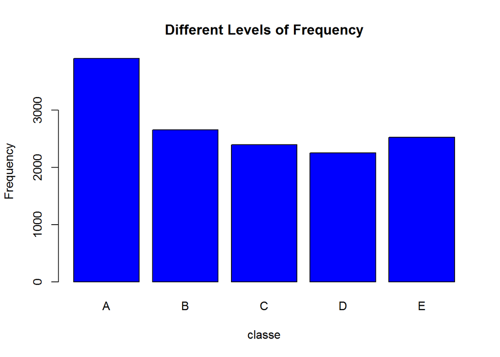

```r
# Plot the Frequency different levels graph

plot(TrainingSet$classe, col="blue", main="Different Levels of Frequency", xlab="classe", ylab="Frequency")
```

# 4. Building the Decision Tree Model

[figure not shown]

```r
set.seed(12345)
modFitDT <- rpart(classe ~ ., data = TrainingSet, method="class", control = rpart.control(method = "cv", number = 10))
fancyRpartPlot(modFitDT)
```

## 5. Building the Random Forest Model

```r
# Fitting model
model1 <- randomForest(classe ~., data=TrainingSet, method="class")

# Predicting
prediction1 <- predict(model1, TestingSet, Type="class")

# Testing
confusionMatrix(prediction1, TestingSet$classe)
```

```
## Confusion Matrix and Statistics
##
##           Reference
## Prediction    A    B    C    D    E
##          A 1672    9    0    0    0
##          B    2 1129    9    0    0
##          C    0    1 1017    9    0
##          D    0    0    0  955    1
##          E    0    0    0    0 1081
##
## Overall Statistics
##
##                Accuracy : 0.9947
##                  95% CI : (0.9925, 0.9964)
##     No Information Rate : 0.2845
##     P-Value [Acc > NIR] : < 2.2e-16
##
##                   Kappa : 0.9933
##  Mcnemar's Test P-Value : NA
##
## Statistics by Class:
##
##                      Class: A Class: B Class: C Class: D Class: E
## Sensitivity            0.9988   0.9912   0.9912   0.9907   0.9991
## Specificity            0.9979   0.9977   0.9979   0.9998   1.0000
## Pos Pred Value         0.9946   0.9904   0.9903   0.9990   1.0000
## Neg Pred Value         0.9995   0.9979   0.9981   0.9982   0.9998
## Prevalence             0.2845   0.1935   0.1743   0.1638   0.1839
## Detection Rate         0.2841   0.1918   0.1728   0.1623   0.1837
## Detection Prevalence   0.2856   0.1937   0.1745   0.1624   0.1837
## Balanced Accuracy      0.9983   0.9945   0.9946   0.9952   0.9995
```

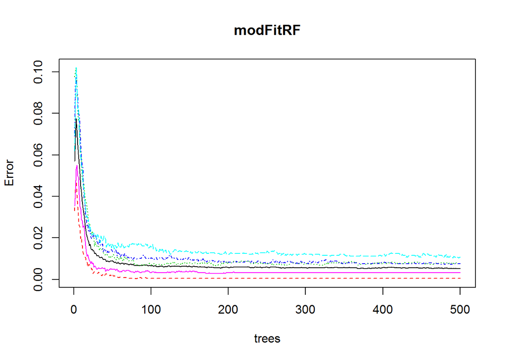

```r
modFitRF <- randomForest(classe ~ ., data = TrainingSet, method = "rf", importance = T, trControl = trainControl(method = "cv", classProbs=TRUE,savePredictions=TRUE,allowParallel=TRUE, number = 10))

plot(modFitRF)
```

# 6. Prediction using Generalized Boosted Model

```r
# Fitting model
fitControl <- trainControl(method="repeatedcv", number=5, repeats=1)
model2 <- train(classe ~., data=TrainingSet, method="gbm", trControl=fitControl, verbose=FALSE)

# Predicting
prediction2 <- predict(model2, TestingSet)

# Testing
confusionMatrix(prediction2, TestingSet$classe)
```

```
## Confusion Matrix and Statistics
##
##           Reference
## Prediction    A    B    C    D    E
##          A 1652   34    0    0    1
##          B   16 1078   32    4   15
##          C    3   25  978   31    4
##          D    3    2   14  929   14
##          E    0    0    2    0 1048
##
## Overall Statistics
##
##                Accuracy : 0.966
##                  95% CI : (0.9611, 0.9705)
##     No Information Rate : 0.2845
##     P-Value [Acc > NIR] : < 2.2e-16
##
##                   Kappa : 0.957
##  Mcnemar's Test P-Value : 1.677e-07
##
## Statistics by Class:
##
##                      Class: A Class: B Class: C Class: D Class: E
## Sensitivity            0.9869   0.9464   0.9532   0.9637   0.9686
## Specificity            0.9917   0.9859   0.9870   0.9933   0.9996
## Pos Pred Value         0.9793   0.9415   0.9395   0.9657   0.9981
## Neg Pred Value         0.9948   0.9871   0.9901   0.9929   0.9930
## Prevalence             0.2845   0.1935   0.1743   0.1638   0.1839
## Detection Rate         0.2807   0.1832   0.1662   0.1579   0.1781
## Detection Prevalence   0.2867   0.1946   0.1769   0.1635   0.1784
## Balanced Accuracy      0.9893   0.9662   0.9701   0.9785   0.9841
```

```r
predictTest <- predict(model1, TestingData)
predictTest
```

```
##  1  2  3  4  5  6  7  8  9 10 11 12 13 14 15 16 17 18 19 20
##  B  A  B  A  A  E  D  B  A  A  B  C  B  A  E  E  A  B  B  B
## Levels: A B C D E
```